# Story

Pedestrian activity in any country is a symbol of vibrancy and vitality. An automated pedestrian counting system developed by the City of Melbourne enabled the development of an information repository that can be utilized to analyze the activity of residents across different parts of the city. The pedestrian counting sensors installed in various locations across the city transmit data to a central server which can then be utilized towards better decision making and planning for the future. This project aims to analyse the pedestrian traffic in the target location. It will estimate the pedestrian count at a specific sensor by produce a snap live chart, a live line chart and compare to historical to make business decision. For example, if a pedestrian count of today is more than 4-week average 50%, near restaurants from the sensor will prepare more than 50% materials and seat to serve customers.

# Install Packages

## Mapbox GL Jupyter

Create Mapbox GL JS data visualizations natively in Jupyter Notebooks with Python and Pandas. mapboxgl is a high-performance, interactive, WebGL-based data visualization tool that drops directly into Jupyter. mapboxgl is similar to Folium built on top of the raster Leaflet map library, but with much higher performance for large data sets using WebGL and Mapbox Vector Tiles. This package is used to visualise a live pedestrian map.

```python
!pip install mapbox
```

[output not shown]

## Sodopy

The official Socrata Open Data API docs provide thorough documentation of the available methods, as well as other client libraries. A quick list of eligible domains to use with this API is available via the Socrata Discovery API or Socrata's Open Data Network.

This library supports writing directly to datasets with the Socrata Open Data API. For write operations that use data transformations in the Socrata Data Management Experience (the user interface for creating datasets), use the Socrata Data Management API. For more details on when to use SODA vs the Data Management API, see the Data Management API documentation. A Python SDK for the Socrata Data Management API can be found at socrata-py.

This package is used to download the data from https://data.melbourne.vic.gov.au.

```python
!pip install sodapy
```

## Selenium

In an agile environment, developers emphasize pushing changes quickly. With every change that requires a modification to the front end, they need to run appropriate cross browser tests. While a small project may choose manual testing, an increasing number of browsers make a case for automation testing. In this post, we provide a step-by-step tutorial of web automation testing through Selenium and Python.

Selenium allows you to define tests and automatically detect the results of these tests on a pre-decided browser. A suite of Selenium functions enables you to create step-by-step interactions with a webpage and assess the response of a browser to various changes. You can then decide if the response of the browser is in line with what you expect.

We use this package to crawl the data from http://www.pedestrian.melbourne.vic.gov.au step-by-step.

```python
!dpkg --configure -a
!pip install selenium
!pip install mapboxgl
!apt-get update
!apt install chromium-chromedriver
```

[output not shown]

[output cut: 30 more lines]

[output not shown]

# Import Library

```python
# write your import and necessary web crawling libary here
from selenium import webdriver
from selenium.webdriver.common.keys import Keys
from bs4 import BeautifulSoup
from time import sleep
import sys
from datetime import date
import csv
import pandas as pd
import numpy as np
import selenium
from calendar import monthrange
import time
from sodapy import Socrata
from mapboxgl.viz import *
from mapboxgl.utils import *
import datetime
import time
from csv import reader
import warnings
warnings.filterwarnings('ignore')
import matplotlib.pyplot as plt
```

```python
warnings.filterwarnings(action='once')
```

# Live Map

### Sensor Location

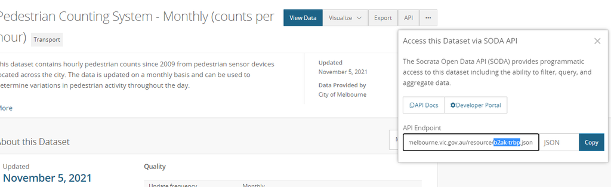

```python
#This function is used to crawl the sensor location system
def sensor_location():
    client = Socrata('data.melbourne.vic.gov.au', None)
    results = client.get('h57g-5234')
    df = pd.DataFrame.from_records(results)
    sensor_location = df[["sensor_id", "sensor_description", "latitude", "longitude"]]
    sensor_location.columns = ["Sensor ID", "Sensor Description", "lat", "lon"]
    sensor_location["lat"] = sensor_location["lat"].apply(lambda x: float(x))
    sensor_location["lon"] = sensor_location["lon"].apply(lambda x: float(x))
    return sensor_location
```

### Hourly Pedestrian Count (Updated every 15 minutes)

https://data.melbourne.vic.gov.au/Transport/Pedestrian-Counting-System-Past-Hour-counts-per-mi/d6mv-s43h

This dataset contains minute by minute directional pedestrian counts for the last hour from pedestrian sensor devices located across the city. The data is updated every 15 minutes and can be used to determine variations in pedestrian activity throughout the day. The sensor_id column can be used to merge the data with the Sensor Locations dataset which details the location, status and directional readings of sensors. Any changes to sensor locations are important to consider when analysing and interpreting historical pedestrian counting data.

Note this dataset may not contain a reading for every sensor for every minute as sensor devices only create a record when one or more pedestrians have passed underneath the sensor.

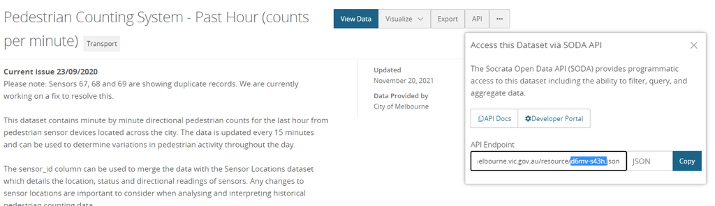

```python
#This function is used to crawl the sensor location system
def minute_count():
    #Crawl the dataset
    client = Socrata('data.melbourne.vic.gov.au', None)
    results = client.get('d6mv-s43h')
    df = pd.DataFrame.from_records(results)
    df = df[["date_time", "sensor_id","total_of_directions"]]

    df.columns = ["DateTime", "Sensor ID", "Count"]
    weekdays = {
    0: "Monday",
    1: "Tuesday",
    2: "Wednesday",
    3: "Thursday",
    4: "Friday",
    5: "Saturday",
    6: "Sunday"
    }
    times = df["DateTime"]
    last_time = times.sort_values(ascending=False).iloc[1].split("T")
    weekday = time.strptime(last_time[0],"%Y-%m-%d").tm_wday

    #Print the last update information of the data
    print(f"The latest data was updated on {weekdays[weekday]} {last_time[0]} at {last_time[1].split('.')[0] } at https://data.melbourne.vic.gov.au")

    df["Count"] = pd.to_numeric(df["Count"])
    counting = df[["Sensor ID", "Count"]].groupby(["Sensor ID"]).sum()
    counting.reset_index(level=0, inplace=True)
    location = sensor_location()
    location["Sensor ID"] = location["Sensor ID"].apply(lambda x: str(x))

    #Merge 2 dataset into 1 datset
    counting = pd.merge(counting, location, on='Sensor ID', how='inner')
    counting["Count"] = counting["Count"].apply(lambda x: float(x))
    return counting
```

```python
counting = minute_count()
```

```
WARNING:root:Requests made without an app_token will be subject to strict throttling limits.
WARNING:root:Requests made without an app_token will be subject to strict throttling limits.
```

```
The latest data was updated on Friday 2021-11-19 at 22:56:00 at https://data.melbourne.vic.gov.au
```

```python
#Add token of Mapbox
token = "pk.eyJ1IjoiZHVuZ2h1eW5oMTEwNDk2IiwiYSI6ImNrdzIxNW05dTA5MTkyb3B4ZjFraG11a3AifQ.vh2SoC9bXNb4VT7jfJU_wA"
```

```python
#USe Mapbox to visualize a snap map
def visualization(token, counting):
    negative_colours = ['rgb(255,255,204)',
          'rgb(255,237,160)',
          'rgb(254,217,118)',
          'rgb(254,178,76)',
          'rgb(253,141,60)',
        'rgb(252,78,42)',
         'rgb(227,26,28)',
         'rgb(189,0,38)',
         'rgb(128,0,38)']
    min_value, max_value = counting["Count"].min(), counting["Count"].max()
    bin_value = (max_value - min_value)/len(negative_colours)
    range_values = [int(min_value + bin_value*i) for i in range(len(negative_colours))]
    negative_color_stops = [[range_values[i], negative_colours[i]] for i in range(len(negative_colours))]
    counting = df_to_geojson(counting, properties=['Sensor ID', 'Count', 'Sensor Description'])
    viz = CircleViz(counting,
                 access_token=token,
                 height='400px',
                 color_property='Count',
                 color_function_type='interpolate',
                 color_stops=negative_color_stops ,
                 radius=2,
                 zoom=13,
                 center=[144.967, -37.8167],
                 below_layer='waterway-label',
                 legend_key_shape='contiguous-bar',
                 legend_key_borders_on=False)
    viz.legend_layout = 'horizontal'
    viz.legend_key_borders_on = True
    viz.legend_key_shape = 'contiguous-bar'
    viz.legend_text_numeric_precision = 0
    viz.legend_key_borders_on = False
    viz.legend_gradient = True
    viz.legend = True
    viz.show()
```

```python
visualization(token, counting)
```

[interactive chart not shown]

[figure not shown]

# Line Chart

The data is available in the Pedestrian Counting System. This data conist of dta of hourly of the date, 4-week everage and 2 years average.

[figure not shown]

We use Selenium with 2 steps to crawl the data. Firstly, we use function **driver.find_element_by_xpath(f'//*[@id="dropdown-size-small"]').click()** to click the download box.

[figure not shown]

One white box then appear named **CSV dat of selected day**

[figure not shown]

Then we will click this box to download the data by using **driver.find_element_by_xpath(f'/html/body/div/div/div[5]/div[2]/div/ul/li/a').click()**. Because we need some minutes to download the data, then we use **sleep(5)** to download and load the data.

```python
#Set up Google Chrome Drive
sys.path.insert(0,'/usr/lib/chromium-browser/chromedriver')
chrome_options = webdriver.ChromeOptions()
chrome_options.add_argument('--headless')
chrome_options.add_argument('--no-sandbox')
chrome_options.add_argument('--disable-dev-shm-usage')
```

```python
def daily_monthly_yearly_data():
      #Crawl data
    driver= webdriver.Chrome('chromedriver',chrome_options=chrome_options)
    #Load the website
    driver.get("http://www.pedestrian.melbourne.vic.gov.au/")
    #Click Download Box
    driver.find_element_by_xpath(f'//*[@id="dropdown-size-small"]').click()
    sleep(2)
    #Click the white box to download CSV file
    driver.find_element_by_xpath(f'/html/body/div/div/div[5]/div[2]/div/ul/li/a').click()
    sleep(5)
    today = date.today()
    today = today.strftime("%d-%m-%Y")
    file_name = f"COM_24PM_{today}.csv"\
    #Cleaning data
    with open(file_name, 'r') as read_obj:
        csv_reader = reader(read_obj)
        daily_data = {}
        monthly_data = {}
        yearly_data = {}
        i = 0
        for row in csv_reader:
            if i in range(9, 87):
                daily_data[row[0]] =  row[1:]
            elif i in range(91,169):
                monthly_data[row[0]] =  row[1:]
            elif i in range(173,251):
                yearly_data[row[0]] =  row[1:]
            i+=1
        for sensor in daily_data:
            if len(daily_data[sensor]) == 0:
                  daily_data[sensor] = [np.nan]*24
        for sensor in monthly_data:
            if len(monthly_data[sensor]) == 0:
                monthly_data[sensor] = [np.nan]*24
        for sensor in yearly_data:
            if len(yearly_data[sensor]) == 0:
                  yearly_data[sensor] = [np.nan]*24
        #Convert string to number
        daily_data = pd.DataFrame(daily_data)
        monthly_data = pd.DataFrame(monthly_data)
        yearly_data = pd.DataFrame(yearly_data)
        daily_data = daily_data.replace("N/A", np.nan)
        monthly_data = monthly_data.replace("N/A", np.nan)
        yearly_data = yearly_data.replace("N/A", np.nan)
        for column in daily_data.columns:
            daily_data[column] = pd.to_numeric(daily_data[column])
            daily_data = daily_data.replace(0, np.nan)
            monthly_data[column] = pd.to_numeric(monthly_data[column])
            yearly_data[column] = pd.to_numeric(yearly_data[column])
            return daily_data, monthly_data, yearly_data

    daily_data, monthly_data, yearly_data = daily_monthly_yearly_data()

    #Plot line chart
    def line_chart(daily_data_sensor, monthly_data_sensor, yearly_data_sensor, sensor_name):
        hours = [f"0{i}:00" for i in range(0, 10)] + [f"{i}:00" for i in range(10, 24)]
        latest_update = 0
        for i in range(23, -1, -1):
            if daily_data_sensor[i] == daily_data_sensor[i]:
                latest_update = i
                break
        #Compare the data of the date of the historical data
        percent = (daily_data_sensor[latest_update]/monthly_data_sensor[latest_update]) - 1
        compare_value = 0
        if percent > 0:
            compare_value = "more"
        else:
            compare_value = "less"
        print(f"The latest data was updated at {hours[latest_update]}. Compared to 4 week average, the pedestrian number is {compare_value} than {str(percent*100).replace('-','').split('.')[0]}%.")
        plt.figure(figsize=(20, 10))
        plt.plot(hours, daily_data_sensor, label = f'Hourly count of today {hours[latest_update]}.))', linewidth=2)
        plt.plot(hours, monthly_data_sensor, label = '4 Week average', linewidth=2)
        plt.plot(hours, yearly_data_sensor, label = '2 Year average',linewidth=2)
        labels = ["Hourly count of today", '4 Week average', '2 Year average']
        plt.legend(labels, prop={'size': 20})
        plt.grid(color='g', linestyle='-', linewidth=0.1)
        plt.xticks(hours)
        plt.axvline(latest_update, c = "red", linewidth=0.5)
        plt.title(f"Hourly Pedestrian Count at {sensor_name}", fontsize=20)
        plt.xlabel(f"Hour", fontsize=20)
        plt.ylabel(f"Pedestrians", fontsize=20)

#Filter data with input is Sensor ID
def daily_chart(filter_value, daily_data = daily_data, monthly_data =  monthly_data, yearly_data = yearly_data):
    if str(type(filter_value)) == "<class 'int'>":
        if filter_value in range(1, 80):
            sensor_lo = sensor_location()
            sensor = sensor_lo[sensor_lo["Sensor ID"] == str(filter_value)]["Sensor Description"].iloc[0]
            daily_data_sensor = daily_data[sensor]
            monthly_data_sensor = monthly_data[sensor]
            yearly_data_sensor = yearly_data[sensor]
            line_chart(daily_data_sensor, monthly_data_sensor, yearly_data_sensor, sensor)
        else:
            raise("Sensor ID must be from 1 to 78.")
    elif filter_value in ["Melbourne", "melbourne", "Total", "total", 0]:
        daily_data_sensor = daily_data["Total"]
        monthly_data_sensor = monthly_data["Total"]
        yearly_data_sensor = yearly_data["Total"]
        line_chart(daily_data_sensor, monthly_data_sensor, yearly_data_sensor, "Melbourne")
```

```
The latest data was updated at 22:00. Compared to 4 week average, the pedestrian number is more than 60%.
```

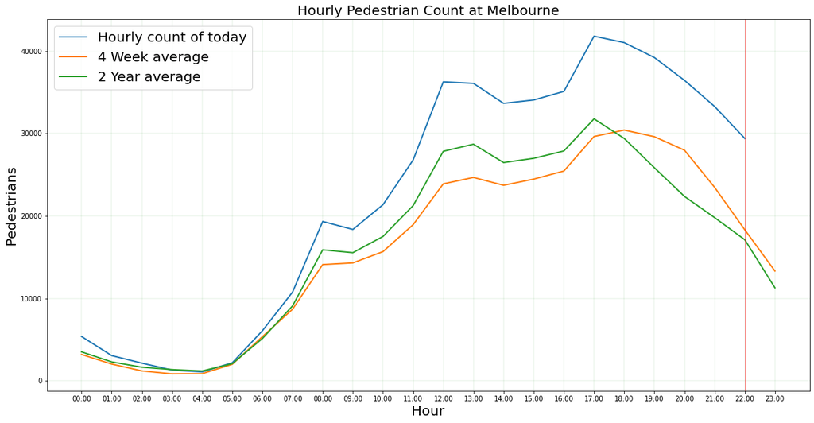

```python
daily_chart("Melbourne")
```

Because the line chart will disappear when we push into github. then we keep a screenshot of the line chart to make sure it is still kept in this file

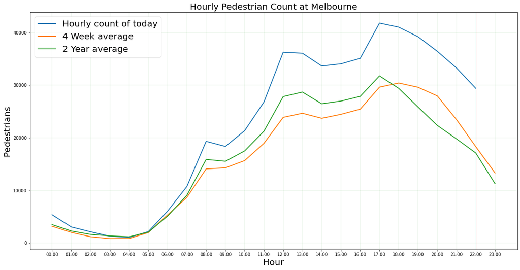

[output not shown]

```
The latest data was updated at 22:00. Compared to 4 week average, the pedestrian number is more than 32%.
```

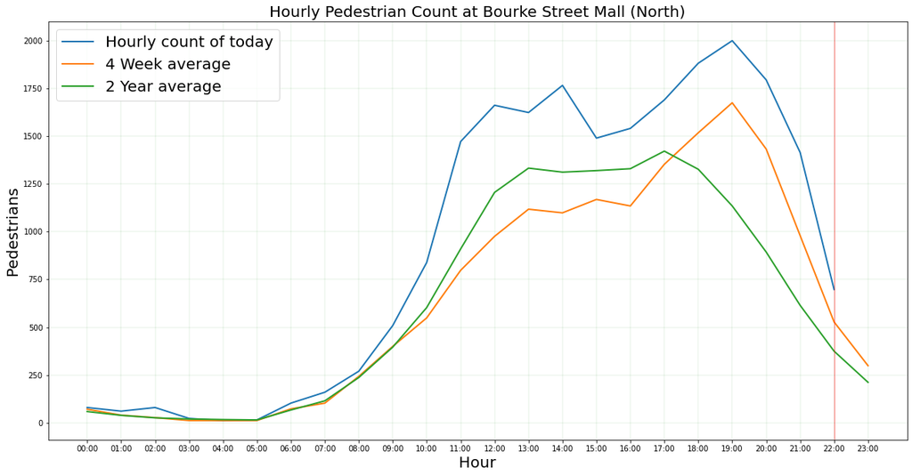

```python
daily_chart(1)
```

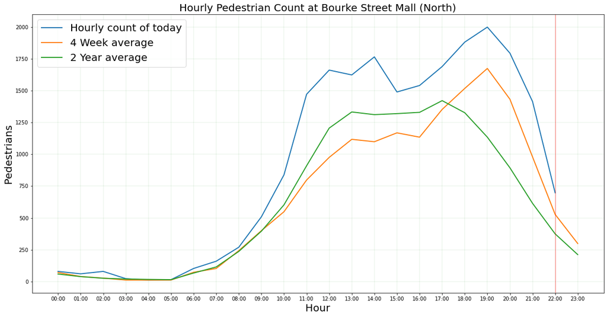